# Forecasting the U.S. Labour Force Participation Rate

Krista Bennatti-Roberts

December 6, 2017

## 1 Introduction

This paper describes the process of developing and choosing a model to forecast U.S. civilian labour force participation rates, hereafter referred to as “participation rates”, over a six-month horizon. A variety of time-series forecasting models were fitted and assessed. Models were compared based on the root-mean square error (RMSE) measure.

The participation rates data is a monthly, non-seasonally adjusted data set from the U.S. Bureau of Labor Statistics and was accessed through the Federal Reserve Bank of St. Louis (FRED) (1). The U.S. Bureau of Labor Statistics defines labor force participation rate as “the percentage of the population either employed or actively seeking work” (2). Unemployed individuals are considered to be participating in the labour force while they are actively looking for work. Military personnel are excluded from the data set.

The participation rates data under analysis ranges from year 1960 through June, 2017. Eighty percent of the data was assigned to a training data set (1960 through 2005) and the remaining 20 percent was assigned to a testing data set.

```r
#libraries:
library(knitr)
library(fpp)
library(forecastHybrid)
library(vars)
#import csv with participation rates
finalproj = read.csv("C:/Users/K/Dropbox/Econ Forecasting/Econ R/Final project/lbrforce.csv")
#this is a time series
lbrTs = ts(finalproj, start = 1960, end = c(2017,6), frequency = 12)
#separate training and testing
train = window(lbrTs, start = c(1960, 1), end = c(2005, 12))
test = window(lbrTs, start = c(2006, 1), end =c(2017,6))
#assign labels to variable columns
trainLbr = train[,2]
testLbr = test[,2]
#define length of testing dataset
h = length(testLbr)
```

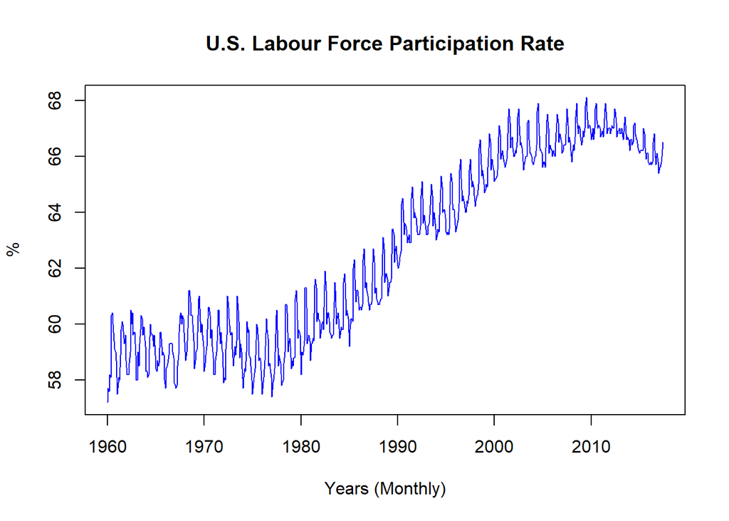

```r
title1 = "U.S. Labour Force Participation Rate"
plot(lbrTs[,2], main = title1, xlab = "Years (Monthly)", ylab = "%", col = "blue")
```

The plot of the participation rates shows that rates increased steadily from around 1980 through year 2000 and have been on the decline from around 2008. The data shows strong seasonality and is clearly non-stationary.

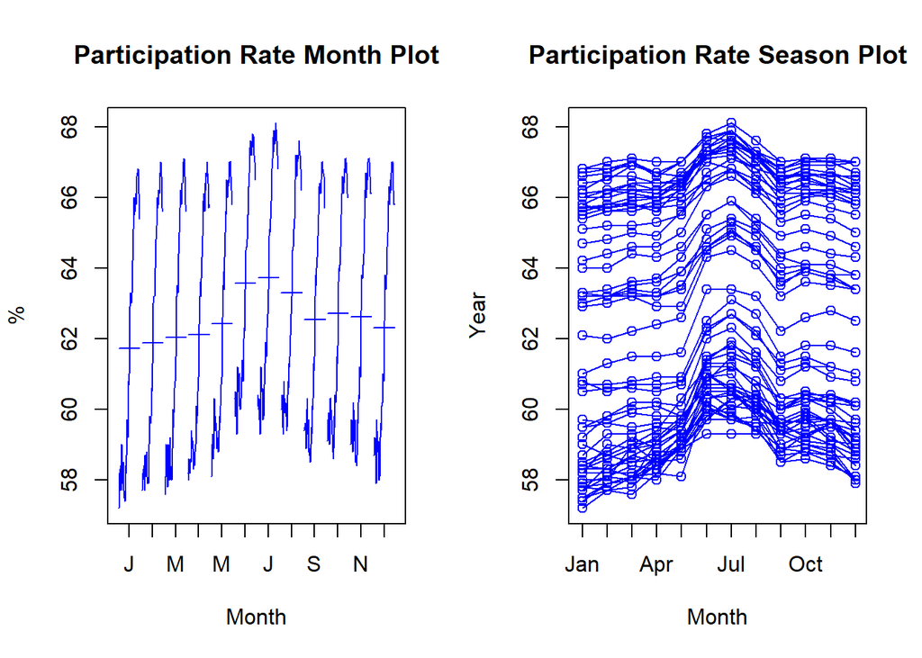

```r
par(mfrow = c(1,2))
monthplot(lbrTs[,2], main = 'Participation Rate Month Plot', xlab = "Month", ylab = "%", col = "blue")
seasonplot(lbrTs[,2], main = 'Participation Rate Season Plot', xlab = "Month", ylab = "Year", col = "blue")
```

Labour force participation rises during the summer, peaking in June and July and dipping over the winter. This seasonal pattern is consistent over time as shown in the season plot. This pattern is consistent with expectations as seasonal jobs tend to be more prolific in the summer.

## 2 Model Fit Assessment (excluding Vector Autoregression)

Thirteen different time-series forecasting models were fit to the training data. The accuracy of the fit was assessed against the test data and ranked according to RMSE. The thirteen different models that were assessed are detailed in the accuracy chart below. The details of all of these models will not be described here in the interest of brevity.

```r
#average
fitMean = meanf(trainLbr, h=h)
#naive
fitnaive = naive(trainLbr, h=h)
#seasonal naive
fitsnaive = snaive(trainLbr, h=h)
#linear trend
tslmlbr = tslm(trainLbr ~ trend)
fittslm = forecast(tslmlbr, h=h)
```

```r
#exponential
fitses = ses(trainLbr, h=h)
#holt-winter's multiplicative
fithw_m = hw(trainLbr, seasonal="multiplicative", h=h)
#holt-winter's damped
fithw_m_d = hw(trainLbr, seasonal="multiplicative", damped = TRUE, h=h)
#error trend seasonl (ETS)
etslbr = ets(trainLbr, model = "ZZZ")
fitets = forecast(etslbr, h=h)
#ARIMA
arima_lbr= auto.arima(trainLbr)
fitarima = forecast(arima_lbr, h=h)
#ANN
annlbr = ets(trainLbr, model = "ANN")
fitann = forecast(annlbr, h=h)
#neural net
netlbr = nnetar(trainLbr)
fitnet = forecast(netlbr, h=h)
#tbats (time series, box-cox, ARMA, trend, seasonal)
tbatslbr = tbats(trainLbr)
fittbats = forecast(tbatslbr, h=h)
```

```r
#hybrid model - combines TBATs and neural networks
hmodlbr = hybridModel(trainLbr, models = "nt")
```

```
## Fitting the nnetar model
## Fitting the tbats model
```

```r
fithmod = forecast(hmodlbr, h=h)
```

```r
#determine accuracy of all models
amean = accuracy(fitMean, testLbr)
anaive= accuracy(fitnaive, testLbr)
asnaive= accuracy(fitsnaive, testLbr)
atslm= accuracy(fittslm, testLbr)
ases= accuracy(fitses, testLbr)
ahwm= accuracy(fithw_m, testLbr)
ahwmd= accuracy(fithw_m_d, testLbr)
aets= accuracy(fitets, testLbr)
aarima = accuracy(fitarima, testLbr)
aann = accuracy(fitann, testLbr)
anet = accuracy(fitnet, testLbr)
atbats = accuracy(fittbats, testLbr)
ahmod = accuracy(fithmod, testLbr)
```

```r
#Combine accuracy into table and sort by RMSE:
accTable = rbind(amean, anaive, asnaive, atslm, ases, ahwm, ahwmd, aets, aarima, aann, anet, atbats, ahmod)
row.names(accTable)= c("Mean Train", "Mean Test","Naive Train", "Naive Test", "Seasonal Naive Train", "Seasonal Naive Test", "Linear Train", "Linear Test", "SES Train", "SES Test","HW Mult. Train", "HW Mult. Test", "HW Damped Train", "HW Damped Test", "ETS Train", "ETS Test", "ARIMA Train", "ARIMA Test", "ANN Train", "ANN Test", "Neural Net Train", "Neural Net Test", "TBATS Train", "TBATS Test", "Hybrid Train", "Hybrid Test")
#order by MASE
accFrame = as.data.frame(accTable)
print(accFrame[order(accFrame$RMSE),])
```

```
##                                 ME      RMSE       MAE           MPE
## ETS Train             1.495906e-03 0.2593526 0.1987382  0.0005443878
## HW Damped Train       2.060193e-02 0.2616164 0.2026214  0.0319037415
## Hybrid Train          1.558780e-02 0.2696835 0.2117726  0.0225661852
## TBATS Train           3.162834e-02 0.2724713 0.2164414  0.0490910548
## HW Mult. Train       -4.575886e-03 0.2846786 0.2216707 -0.0081888468
## Neural Net Train     -2.742373e-04 0.3464623 0.2701709 -0.0037641053
## ARIMA Train           3.700404e-03 0.3542256 0.2700764  0.0010166339
## Seasonal Naive Train  1.670370e-01 0.4591457 0.3588889  0.2647206773
## Hybrid Test           1.622878e-01 0.4798120 0.4070588  0.2399247526
## HW Damped Test        2.157964e-01 0.5191026 0.4444898  0.3213140233
## Neural Net Test      -4.356531e-02 0.5357142 0.4133594 -0.0710944591
## SES Train             1.627519e-02 0.5852836 0.4312062  0.0218498989
## ANN Train             1.604238e-02 0.5853096 0.4314325  0.0214433717
## Naive Train           1.633394e-02 0.5857968 0.4319419  0.0219419398
## Seasonal Naive Test   3.695652e-01 0.6139679 0.5173913  0.5522688985
## TBATS Test            3.312712e-01 0.6311703 0.5165723  0.4954367755
## HW Mult. Test        -1.255794e-01 0.6461721 0.5047652 -0.1916716471
## SES Test              4.833175e-01 0.7358712 0.6021664  0.7179243322
## ANN Test              4.833233e-01 0.7358750 0.6021691  0.7179330199
## Naive Test            4.833333e-01 0.7358816 0.6021739  0.7179480477
## Linear Test          -3.618906e-01 1.0506538 0.7843884 -0.5526178314
## ETS Test             -7.025521e-01 1.1210531 0.7752919 -1.0585093970
## Linear Train          2.168867e-16 1.2635092 1.0274295 -0.0411000633
## ARIMA Test           -8.715362e-01 1.2846923 0.9694093 -1.3162544303
## Mean Train           -9.732176e-16 2.8365098 2.4915630 -0.2080806816
## Mean Test             5.136413e+00 5.1662994 5.1364130  7.6963060768
##                           MAPE       MASE        ACF1 Theil's U
## ETS Train            0.3263941  0.5537596 0.258600428        NA
## HW Damped Train      0.3324922  0.5645796 0.250342127        NA
## Hybrid Train         0.3471493  0.5900786 0.184486738        NA
## TBATS Train          0.3552172  0.6030875 0.004376211        NA
## HW Mult. Train       0.3640245  0.6176584 0.442178931        NA
## Neural Net Train     0.4419389  0.7527980 0.405706433        NA
## ARIMA Train          0.4420087  0.7525348 0.036224487        NA
## Seasonal Naive Train 0.5836424  1.0000000 0.719751208        NA
## Hybrid Test          0.6105421  1.1342197 0.909530407  1.375354
## HW Damped Test       0.6662745  1.2385165 0.872733098  1.486616
## Neural Net Test      0.6212130  1.1517754 0.849876413  1.544739
## SES Train            0.7026576  1.2015034 0.185445586        NA
## ANN Train            0.7030541  1.2021339 0.185046938        NA
## Naive Train          0.7038532  1.2035533 0.185405738        NA
## Seasonal Naive Test  0.7751440  1.4416476 0.817485446  1.754949
## TBATS Test           0.7743465  1.4393655 0.860795884  1.805131
## HW Mult. Test        0.7591261  1.4064665 0.913798163  1.861264
## SES Test             0.8986676  1.6778629 0.795835785  2.097215
## ANN Test             0.8986717  1.6778706 0.795835785  2.097226
## Naive Test           0.8986788  1.6778840 0.795835785  2.097244
## Linear Test          1.1803143  2.1856024 0.930503818  3.034712
## ETS Test             1.1676269  2.1602561 0.944690735  3.236354
## Linear Train         1.6848538  2.8628067 0.892762976        NA
## ARIMA Test           1.4608232  2.7011406 0.930994937  3.713838
## Mean Train           4.0163772  6.9424355 0.974148541        NA
## Mean Test            7.6963061 14.3119868 0.795835785 14.759241
```

Of the models assessed, the best performing, based on RMSE, is the “Hybrid” model which combined the neural network time series model with the TBATS model with equal weightings. It’s performance is closely followed by the Holt-Winter’s multiplicative damped model and the neural network model.

## 3 Vector Auto-Regression Model Assessment

In addition to the models assessed above, the Vector Autoregression Regression (VAR) forecasting model was asessed and compared to the previously assessed models. The objective of fitting a VAR model was to assess whether the addition of explanatory variables could increase forecasting accuracy.

```r
# import data
lbrDataPlus <- read.csv("C:/Users/K/Dropbox/Econ Forecasting/Econ Final Project/relevant data/newdata.csv")
#this is a time series
lbrTsV = ts(lbrDataPlus, start = c(1960,1), end = c(2017,8), frequency = 12)
```

## 3.1 Selecting Explanatory Variables

The explanatory variables chosen for inclusion in the VAR model were as follows: a) working age (15-64) U.S.citizens as a percentage of the total population (“AgePercPop”“), b) U.S. civilian unemployment (”Unempl“”), c) producer price index for fuel and fuel related products (“PPIFuel”). All variables were obtained from the Federal Reserve Bank of St. Louis (3,4,5). These variables were chosen based on the drivers that are believed to have the largest influence on participation rates or proxy measures where these drivers were not available.

Recent changes in labour force participation have likely been driven primarily by three variables: the relative number of working age people in the population (represented by “AgePercPop”), the level of educational attainment in the population (if individuals spend more time in school, labour force participation decreases), and finally, the state of the economy (represented by “Unempl” and “PPIFuel”. The state of the economy impacts labour force participation because if there are few good jobs, people who are less employable or less motivated to work will eventually stop looking for work and therefore stop being considered as part of the numerator. Educational attainment and domestic product, the latter being a proxy measure of the state of the economy are reported annually and quarterly, respectively and therefore could not be integrated into this VAR model. Unemployment was used as a proxy for economic state in lieu of GDP. The PPI of fuels and related products was also included based on the fact that this data set shows notable spikes during recession periods.

In order to prepare the data for VAR modelling, the data was passed through a log function and the variables were ordered with higher-level, macro variables first, followed by lower-level variables. The variables were ordered as follows: a) working age (15-64) U.S.citizens as a percentage of the total population (“AgePercPop”“), b) U.S. civilian unemployment , c) producer price index for fuel and fuel related products , d) participation rates.

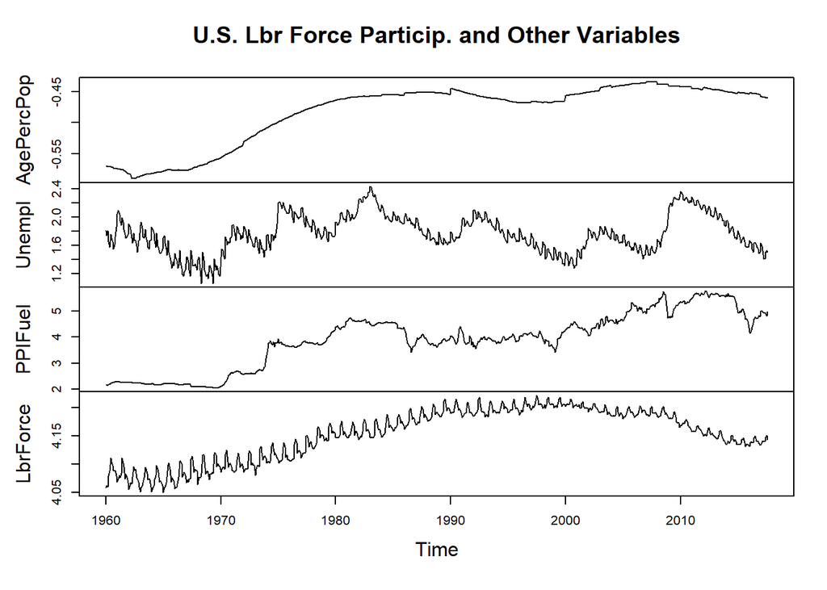

```r
lbrVarTs = log(lbrTsV[,c(3,5,4,2)])
trainVar = window(lbrVarTs, start = c(1960, 1), end = c(2005, 12))
#plot
plot(lbrVarTs, main= 'U.S. Lbr Force Particip. and Other Variables')
```

Of the four variables shown above, the working age as a proportion of the population variable visually appears to best follow the cycle of participation rates.

```r
#correlation matrix
cor(lbrVarTs)
```

```
##            AgePercPop    Unempl   PPIFuel  LbrForce
## AgePercPop  1.0000000 0.3831770 0.9066748 0.8613472
## Unempl      0.3831770 1.0000000 0.4394830 0.1563026
## PPIFuel     0.9066748 0.4394830 1.0000000 0.6798621
## LbrForce    0.8613472 0.1563026 0.6798621 1.0000000
```

This observation is supported by the correlation matrix which shows an 86 percent correlation between the working age as a proportion of the population and participation rates. The PPI of fuel and related products is 68 percent correlated while unemployment shows a weak, positive correlation of about 16 percent. The fact that the correlation is positive is somewhat surprising.

## 3.2 Developing the VAR model

In order to determine the appropriate number of lags to use in the VAR model, a “VARselect” function was applied in R.

```r
varSel = VARselect(trainVar, lag.max = 10, season = 12)
varSel$selection
```

```
## AIC(n)  HQ(n)  SC(n) FPE(n)
##     10      2      1     10
```

All of three possible lag choices for the four information criterion shown above were tried in the model (not shown here) and the Schwartz Criterion was selected for use as it demonstrated the best performance when assessed against the testing data. The Schwartz criterion is less likely to overfit and in this case that was beneficial.

```r
#train the VAR model using the selected number of lags
varTrain.1 = VAR(trainVar, p=varSel$selection[3], season =12) #
```

In general, a good fitting VAR model should have roots of the characteristics polynomial that are less than one as well as random residuals.

```r
#check the roots
roots(varTrain.1)
```

```
## [1] 0.9985941 0.9821968 0.9821968 0.9385323
```

In this case, all roots are below one.

The autocorrelation and partial-autocorrelation plots (see Appendix II) show evidence that the residuals of unemployment versus the participation rates are autocorrelated i.e. not random. The other variables do not show significant autocorrelation for positive lags. Note that plots of variables against themselves can be ignored. The autocorrelation of the residuals for unemployment indicates that the model should be tried with unemployment removed. This was done, however, because predictive performance was ultimately inferior, this exercise is not shown here.

Granger-causality of the three explanatory variables was assessed with labour force participation as the response variable.

```r
#Test Granger-Causality
causality(varTrain.1, cause= c("AgePercPop", "PPIFuel", "Unempl"))
```

```
## $Granger
##
##  Granger causality H0: AgePercPop Unempl PPIFuel do not
##  Granger-cause LbrForce
##
## data:  VAR object varTrain.1
## F-Test = 6.0211, df1 = 3, df2 = 2140, p-value = 0.0004416
##
##
## $Instant
##
##  H0: No instantaneous causality between: AgePercPop Unempl PPIFuel
##  and LbrForce
##
## data:  VAR object varTrain.1
## Chi-squared = 34.971, df = 3, p-value = 1.236e-07
```

There is evidence that the three explanatory variables do Granger-cause labour force participation rates at a 95 percent confidence level. There is also evidence of instantaneous causality i.e. causality without a lag at the same confidence level.

Factor error variance decomposition (see Appendix IV) demonstrates that variance in labour force participation rates is mostly explained by itself. The proportion explained by the other three variables increases slowly over time. By lag 36 labour force participation accounts for about 79 percent of its own variation versus 93 percent at lag 1. Unemployment accounts for a variable amount of variation that decreases in lags one through 13, and increases thereafter. The amount of variation explained by the other two explanatory variables increases steadily but by very small increments over time achieving only about 5 percent and 6 percent, respectively by lag 36.

## 3.3 Assessing the VAR Model

The VAR model fitted on training data was used as the basis to forecast 138 months forward and assessed against the testing data set.

```r
varForecast = predict(varTrain.1, n.ahead = h)
#remove log from forecast
varFit = exp(varForecast$fcst$LbrForce)
varFit = data.frame(varFit)
#accuracy
avar = accuracy(varFit$fcst, testLbr)
avar
```

```
##                  ME      RMSE       MAE        MPE      MAPE      ACF1
## Test set -0.4049001 0.8358746 0.6101832 -0.6106089 0.9182027 0.9019963
##          Theil's U
## Test set   2.40791
```

The VAR model has a RMSE of about 0.84, performing relatively poorly when compared to other models. This VAR model only performs marginally better than the linear trend model.

## 4 Choosing a Final Model and Creating a Forecast

The best performing model remained the hybrid model based on the RMSE metric. This model combined the neural network and TBATs models with equal weightings.

The hybrid model was therefore used to forecast six periods into the future, the forecasting horizon. The resulting forecast is shown below:

```r
hmodFuture = hybridModel(lbrTs[,2], models = 'nt')
```

```
## Fitting the nnetar model
## Fitting the tbats model
```

```r
fitHmodFuture = forecast(hmodFuture, h=6)
summary(fitHmodFuture)
```

```
##
## Forecast method: nnetar with weight 0.5
## Forecast method: tbats with weight 0.5
##
## Model Information:
## NULL
##
## Error measures:
##                      ME      RMSE       MAE        MPE      MAPE      MASE
## Training set 0.01390046 0.2108674 0.1634078 0.02107332 0.2642204 0.4954853
##                     ACF1
## Training set -0.04753956
##
## Forecasts:
##          Point Forecast    Lo 80    Hi 80    Lo 95    Hi 95
## Jul 2017       66.81334 66.50604 67.18527 66.32625 67.36506
## Aug 2017       66.33368 65.92525 66.79936 65.75383 67.01818
## Sep 2017       65.84352 65.32998 66.29269 65.07516 66.54751
## Oct 2017       65.97740 65.37188 66.48282 65.10544 66.66927
## Nov 2017       66.08169 65.48105 66.55145 65.19774 66.83477
## Dec 2017       65.72691 65.05571 66.25488 64.76884 66.48494
```

Visualizations of the hybrid forecast and other forecasts can be found in Appendix I.

## 5 Discussion and Conclusion

The vector autoregression model performed poorly despite the expectation that external variables would help explain the cyclical component of the data set. One may assume that the influences of external variables on participation rates are more complex than the model allowed. Further, the explanatory variables used to compose the data set were not ideal as more appropriate variables were not available at a monthly frequency.

Overall, the best performance was acheived using a combined model that leveraged both the neural network and TBATS modelling methods.

### Bibliography:

1. U.S. Bureau of Labor Statistics, Civilian Labor Force Participation Rate [LNU01300000], retrieved from FRED, Federal Reserve Bank of St. Louis; https://fred.stlouisfed.org/series/LNU01300000, December 6, 2017.
2. “Labor Force Statistics from the Current Population Survey: How the Government Measures Unemployment”, United States Department of Labor, Bureau of Labor Statistics, retrieved from: https://www.bls.gov/cps/cps_htgm.htm#definitions, December 6, 2017.
3. Organization for Economic Co-operation and Development, Working Age Population: Aged 15-64: All Persons for the United States [LFWA64TTUSM647N], retrieved from FRED, Federal Reserve Bank of St. Louis; https://fred.stlouisfed.org/series/LFWA64TTUSM647N, December 3, 2017.
4. U.S. Bureau of Labor Statistics, Civilian Unemployment Rate [UNRATENSA], retrieved from FRED, Federal Reserve Bank of St. Louis; https://fred.stlouisfed.org/series/UNRATENSA, December 3, 2017.
5. U.S. Bureau of Labor Statistics, Producer Price Index by Commodity for Fuels and Related Products and Power [WPU0574], retrieved from FRED, Federal Reserve Bank of St. Louis; https://fred.stlouisfed.org/series/WPU0574, December 3, 2017.

### Appendix I: Forecast Plots

Plot of the hybrid model forecast over a six-month horizon:

[output not shown]

Plot of the hybrid forecast against testing data:

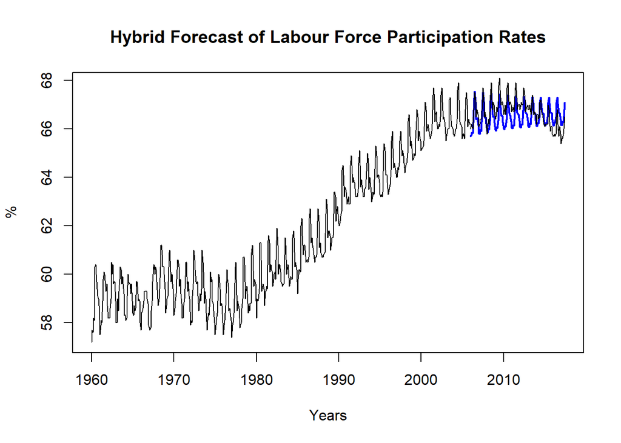

```r
plot(fithmod, xlab = "Years", ylab ='%', main = 'Hybrid Forecast of Labour Force Participation Rates', PI = FALSE)
lines(testLbr)
```

Plot of the hybrid forecast compared with other high performing forecasts:

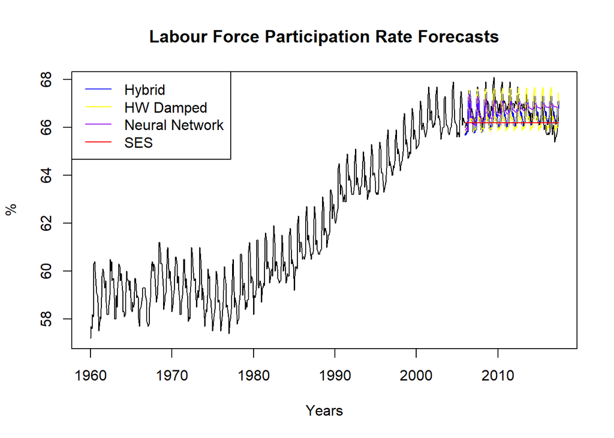

```r
plot(fithmod, xlab = "Years", ylab ='%', main = 'Labour Force Participation Rate Forecasts', PI = FALSE)
lines(testLbr)
lines(fithw_m_d$mean, col = 'yellow')
lines(fitnet$mean, col = 'purple')
lines(fitses$mean, col = 'red')
legend('topleft', lty =1, col =c('Blue','Yellow','Purple', 'Red'),
       legend = c('Hybrid', 'HW Damped', 'Neural Network', 'SES'))
```

### Appendix II: Residual Plots (Vector Autoregression)

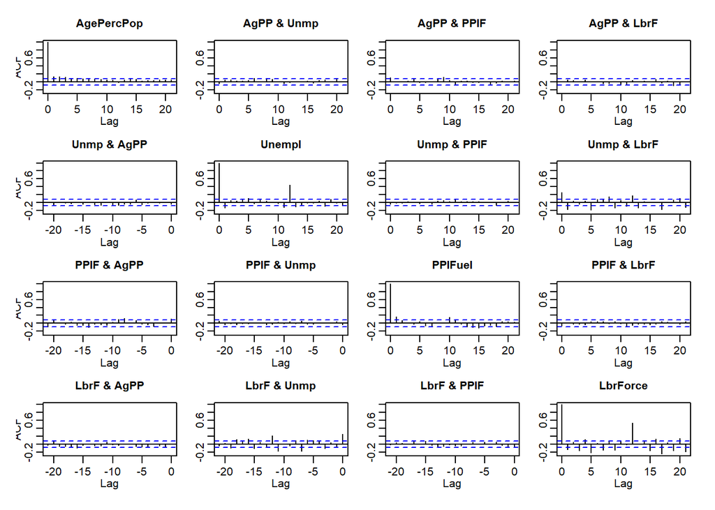

```r
#Check residuals:
acf(residuals(varTrain.1))
```

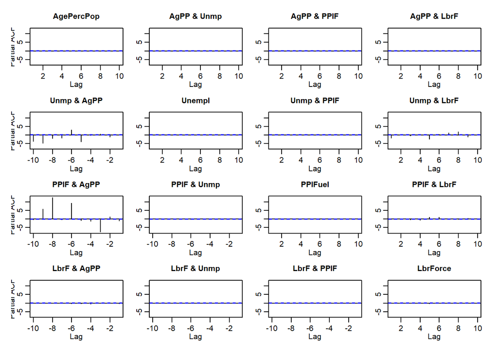

```r
acf(residuals(varTrain.1), type="partial", lag.max=10)
```

### Appendix III: Impulse Response Function Plots

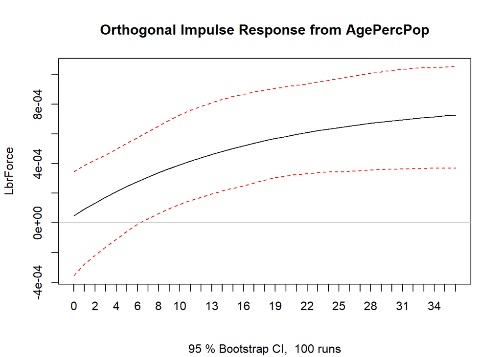

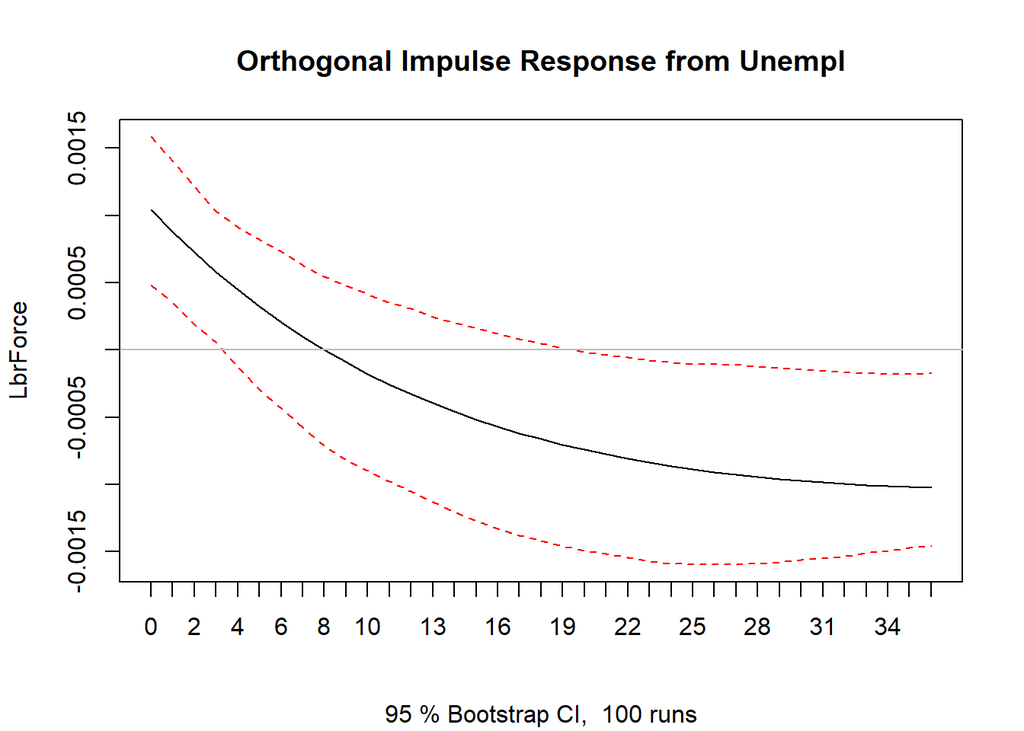

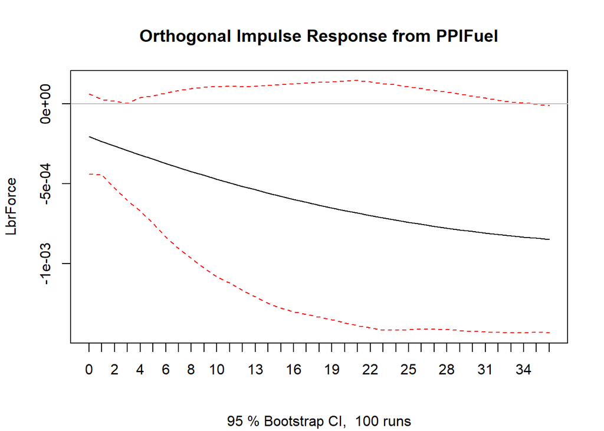

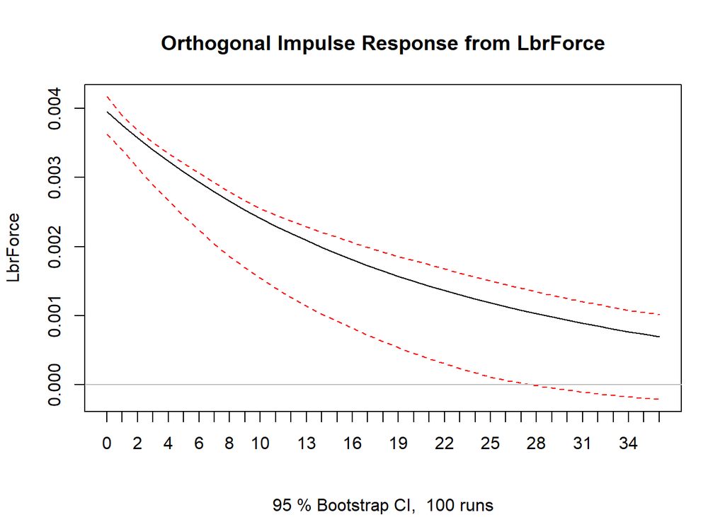

```r
#Impules response
plot( irf(varTrain.1, response = "LbrForce", n.ahead = 36, boot = TRUE) , plot.type = "single")
```

### Appendix IV: Factor Error Variance Decompositions

```r
varFevd = fevd(varTrain.1, n.ahead = 36)
varFevd$LbrForce
```

```
##         AgePercPop     Unempl     PPIFuel  LbrForce
##  [1,] 0.0001385593 0.06513102 0.002499207 0.9322312
##  [2,] 0.0003435001 0.05877546 0.003046665 0.9378344
##  [3,] 0.0006422223 0.05297762 0.003673250 0.9427069
##  [4,] 0.0010363719 0.04774997 0.004382900 0.9468308
##  [5,] 0.0015268970 0.04310036 0.005179041 0.9501937
##  [6,] 0.0021140448 0.03903200 0.006064537 0.9527894
##  [7,] 0.0027973719 0.03554351 0.007041654 0.9546175
##  [8,] 0.0035757664 0.03262916 0.008112026 0.9556830
##  [9,] 0.0044474825 0.03027904 0.009276643 0.9559968
## [10,] 0.0054101841 0.02847939 0.010535849 0.9555746
## [11,] 0.0064609970 0.02721296 0.011889346 0.9544367
## [12,] 0.0075965679 0.02645942 0.013336216 0.9526078
## [13,] 0.0088131276 0.02619574 0.014874947 0.9501162
## [14,] 0.0101065574 0.02639671 0.016503470 0.9469933
```

[output cut: 22 more lines]